# Homework: Simulation

Example: Set

> Note, these instructions are for an old version of this assignment. I have provided the sample file for demonstration purposes and to add an extra example.

## Is it in the cards?

In this task, you will create a simulation of a card or dice game of your choice. You might consider games such as set, [farkle](https://www.dicegamedepot.com/farkle-rules/), [blackjack](https://bicyclecards.com/how-to-play/blackjack/#filter), [war](https://bicyclecards.com/how-to-play/war/#filter), or [go fish](https://bicyclecards.com/how-to-play/go-fish/#filter). You may choose any game that can be assessed probabilistically – you may want to avoid games which require a large amount of strategy, skill, and bluffing, such as poker.

You don’t need to necessarily simulate the full game mechanism, but you do need to implement enough of the game mechanism that you can identify an interesting probability question in your game and answer the question using a simulation.

### Scenario Description

[figure not shown]

Set game box

Set is a card game based on combinations. There are 4 different characteristics of a set card:

- number of shapes (1, 2, 3)
- shape fill (solid, empty, lines)
- shape type (oval, squiggle, diamond)
- color (red, green, purple)

There are thus 3x3x3x3 = 81 cards in a set deck. [See the full deck here](https://upload.wikimedia.org/wikipedia/commons/8/8e/Set_isomorphic_cards.svg)

A set consists of 3 cards which are either all the same or all different across each characteristic.

[figure not shown]

A set where each card is completely different (across all 4 dimensions)

You can try set out online [here](https://smart-games.org/en/set_classic/start/20).

### Set up your objects

First, you must set up a data frame describing all possible values of your playing items. For instance, if you are using a standard deck of 52 playing cards, you’ll need a data frame which has columns for suit and value, and you may want to make value a factor variable (your call on that one). If your game requires that players hold cards in their hand, you may also want to have a column indicating location (deck, discard, player_x).

```r
library(tidyverse)

set_deck <- tidyr::crossing(
  num = 1:3,
  color = c("red", "green", "purple"),
  shape = c("oval", "diamond", "tilde"),
  fill = c("solid", "empty", "lines")
) %>%
  mutate(card_id = 1:n(),
         card_location = "deck")
```

I’ve added a `card_id` number to each card for reasons that will become clear later…

### Write one or more functions to simulate the basic game mechanisms

For instance, if you are simulating set, you need to have a function that draws 12 cards from the deck. You may want an auxiliary function which determines if a set is present.

I’ve added a note parameter that will track which round each card was dealt on; don’t worry about it for now.

```r
deal_set <- function(deck, n = 12, note = NA) {
  available <- filter(deck, card_location == "deck")
  if (nrow(available) < n) {
    # if there are fewer cards available than requested, deal any remaining cards
    dealt_cards <- available$card_id
  } else {
    # otherwise, sample
    dealt_cards <- sample(available$card_id, size = n, replace = F)
  }

  deck <- deck %>%
    mutate(card_location = ifelse(card_id %in% dealt_cards, "table", card_location))

  return(deck)
}

deal_set(set_deck) %>%
  filter(card_location != "deck")
```

```
## # A tibble: 12 × 6
##      num color  shape   fill  card_id card_location
##    <int> <chr>  <chr>   <chr>   <int> <chr>
##  1     1 green  tilde   empty       7 table
##  2     1 purple oval    empty      13 table
##  3     1 purple oval    lines      14 table
##  4     1 purple tilde   solid      18 table
##  5     1 red    diamond empty      19 table
##  6     2 green  diamond solid      30 table
##  7     2 green  oval    lines      32 table
##  8     2 red    diamond lines      47 table
##  9     2 red    oval    solid      51 table
## 10     2 red    tilde   lines      53 table
## 11     3 green  tilde   solid      63 table
## 12     3 red    oval    empty      76 table
```

If a set is present, then we would remove it and add 3 new cards; if a set is not present, then we would add 3 new cards (this is a rare event, according to the rules).

A set can be determined uniquely from any two cards; if the cards are the same on one dimension, then the third card needs to be the same, otherwise, it needs to be different.

```r
# This function does the hard work - if an attribute is the same across 2 given things,
# it returns the same value. Otherwise, it returns the "other" value not listed.
attrib_coalesce <- function(given, options) {
  if (length(unique(given)) == 1) {
    unique(given) # return the same value
  } else {
    setdiff(options, given) # return the diff value
  }
}
```

Then, we test the logic:

```r
attrib_coalesce(c("red", "red"), unique(set_deck$color))
```

```
## [1] "red"
```

```r
attrib_coalesce(c("red", "green"), unique(set_deck$color))
```

```
## [1] "purple"
```

To define a card, we need to get one attribute for each of 4 categories. So the `make_set` function takes two id numbers (and the corresponding deck) and picks the 3rd card required for the set.

There are more elegant ways to do this, but the for loop is the most understandable

```r
make_set <- function(id1, id2, deck = set_deck) {
  opts <- tibble(
    num = 1:3,
    color = c("red", "green", "purple"),
    shape = c("oval", "diamond", "tilde"),
    fill = c("solid", "empty", "lines")
  )
  cards <- filter(set_deck, card_id %in% c(id1, id2))

  attr_list <- c("num", "color", "shape", "fill")

  card3 <- cards[1,1:4]
  # this just gets the correct structure with a single row

  for (i in attr_list) { # leave out id
    card3[,i] <- attrib_coalesce(cards[[i]], opts[[i]])
  }

  card3 <- inner_join(set_deck, card3, by = attr_list) # get the card ID out from the attributes
  return(card3$card_id)
}
```

Now, we have the ability to make a set from any two given cards. I’ve used id values here because it’s simpler (but it depends on each card having an ID number as defined above).

Let’s test this function out:

```r
filter(set_deck, card_id %in% c(1, 2, make_set(1, 2)))
```

```
## # A tibble: 3 × 6
##     num color shape   fill  card_id card_location
##   <int> <chr> <chr>   <chr>   <int> <chr>
## 1     1 green diamond empty       1 deck
## 2     1 green diamond lines       2 deck
## 3     1 green diamond solid       3 deck
```

```r
filter(set_deck, card_id %in% c(1, 53, make_set(1, 53)))
```

```
## # A tibble: 3 × 6
##     num color  shape   fill  card_id card_location
##   <int> <chr>  <chr>   <chr>   <int> <chr>
## 1     1 green  diamond empty       1 deck
## 2     2 red    tilde   lines      53 deck
## 3     3 purple oval    solid      69 deck
```

```r
filter(set_deck, card_id %in% c(59, 53, make_set(59, 53)))
```

```
## # A tibble: 3 × 6
##     num color  shape   fill  card_id card_location
##   <int> <chr>  <chr>   <chr>   <int> <chr>
## 1     1 purple diamond lines      11 deck
## 2     2 red    tilde   lines      53 deck
## 3     3 green  oval    lines      59 deck
```

So then to play set we need to build a list of all valid sets (so that we can check whether a set of cards contains a valid set…). This takes forever to run, so I’ve run it once and saved the result.

```r
all_2_card_combos <- crossing(card1 = set_deck$card_id, card2 = set_deck$card_id) %>%
  # get rid of duplicates (card1, card2) is the same as (card2, card1)
  filter(card1 > card2)

# I'm using purrr here but you could do this with a loop;
# I just am lazy and don't want to write the code...
# I haven't figured out how to do this without duplicating some sets... :(
all_sets <- all_2_card_combos %>%
  mutate(card3 = purrr::map2_int(card1, card2, make_set),
         set_id = 1:n())

# Cleaning up a bit to remove duplicates
all_sets <- all_sets %>%
  # first, move to long form so that order is fixed
  pivot_longer(cols = -set_id, names_to = "card_num", values_to = "card_id") %>%
  group_by(set_id) %>%
  arrange(set_id, card_id) %>%
  mutate(card_num = 1:n()) %>%
  # then, move to wide form and identify duplicates
  pivot_wider(names_from = card_num, names_prefix = "card", values_from = card_id) %>%
  group_by(card1, card2, card3) %>%
  arrange(set_id) %>%
  # remove duplicates
  slice_head(n = 1) %>%
  # move back to long form
  pivot_longer(starts_with("card"), names_to = "card_num", values_to = "card_id") %>%
  select(-card_num)

save(set_deck, all_sets, file = "Set_Data.Rdata")
```

```r
load("Set_Data.Rdata")
```

Now, we need a way to check whether there is a set in the 12 cards which are dealt (e.g. on the table)

```r
set_present <- function(deck, setlist = all_sets) {
  cards <- filter(deck, card_location == "table")
  # If there are no cards on the table, return an empty list
  if (nrow(cards) == 0) return(tibble(set_id = NULL, n = 3))

  res <- inner_join(setlist, cards, by = "card_id") %>%
    group_by(set_id) %>%
    count() %>%
    filter(n == 3) %>%
    ungroup()

  return(res)
}
```

Lets make sure this function actually works as expected

```r
set.seed(2034902)
dealt_cards <- deal_set(set_deck)

# Testing it out
res <- dealt_cards %>% set_present()

table_cards <- dealt_cards %>%
  filter(card_location == "table")

table_cards
```

```
## # A tibble: 12 × 6
##      num color  shape   fill  card_id card_location
##    <int> <chr>  <chr>   <chr>   <int> <chr>
##  1     1 green  diamond solid       3 table
##  2     1 green  oval    solid       6 table
##  3     1 green  tilde   empty       7 table
##  4     1 green  tilde   lines       8 table
##  5     1 red    oval    lines      23 table
##  6     1 red    oval    solid      24 table
##  7     2 green  diamond solid      30 table
##  8     2 purple oval    solid      42 table
##  9     2 red    oval    lines      50 table
## 10     2 red    oval    solid      51 table
## 11     3 green  tilde   empty      61 table
## 12     3 red    diamond lines      74 table
```

```r
# Get card numbers in each set
left_join(res, all_sets, by = "set_id") %>%
  # See if the selected cards are actually in the proper set
  left_join(table_cards, by = "card_id")
```

```
## # A tibble: 3 × 8
##   set_id     n card_id   num color  shape   fill  card_location
##    <int> <int>   <int> <int> <chr>  <chr>   <chr> <chr>
## 1    827     3       7     1 green  tilde   empty table
## 2    827     3      42     2 purple oval    solid table
## 3    827     3      74     3 red    diamond lines table
```

So in this example, only one set is on the board, and we would have no choice but to remove that set.

Then, we need to write something to keep track of what cards are still on the table (e.g. we need to remove a set of 3 cards from the table if there is a set present). We can update the location of these cards as in the discard pile.

We might also want to track what round something was removed or dealt in; to do that it will be helpful to write a helper function

```r
add_note_col <- function(deck, index, name, value) {
  if (!name %in% names(deck)) {
    deck[[name]] <- NA
  }

  deck[[name]][index] <- value

  return(deck)
}
```

This function checks to see if a column exists first, and if not, it creates the column. Then, it sets `index` values of the column named `name` to `value` and returns the deck. This way, we can use this function to track both when a card is dealt, and when the card is then removed by passing different note-column names into the function.

Now that we have our helper function, we can write the `remove_set` function and add the note functionality to our `deal_set` function.

```r
remove_set <- function(deck, note = NA) {
  # note allows us to keep track of e.g. what round a set was selected on...
  cards <- filter(deck, card_location == "table")

  # removes a random set of the list of sets which are present
  sets <- set_present(cards)

  if (nrow(sets) > 0)  {
    set_removed <- sets %>%
      slice_sample(n = 1) %>%
      left_join(all_sets, by = "set_id") %>%
      left_join(cards, by = "card_id")

    deck <- deck %>%
      mutate(idx = card_id %in% set_removed$card_id) %>%
      mutate(card_location = ifelse(idx, "discard", card_location))

    if (!is.na(note)) {
      deck <- add_note_col(deck, deck$idx, "remove_note", note)
    }


    deck <- arrange(deck, desc(card_location)) %>%
      select(-idx)
  }

  return(deck)
}

# Update deal_set function to handle a note if we want it to...
deal_set <- function(deck, n = 12, note = NA) {
  available <- filter(deck, card_location == "deck")
  if (nrow(available) < n) {
    # if there are fewer cards available than requested, deal any remaining cards
    dealt_cards <- available$card_id
  } else {
    # otherwise, sample
    dealt_cards <- sample(available$card_id, size = n, replace = F)
  }

  deck <- deck %>%
    mutate(idx = card_id %in% dealt_cards) %>%
    mutate(card_location = ifelse(idx, "table", card_location))

  if (!is.na(note)) {
    deck <- add_note_col(deck, deck$idx, "deal_note", note)
  }

  return(deck %>% select(-idx))
}
```

Let’s test this out:

```r
set.seed(42093482)
res <- deal_set(set_deck, note = 1) %>%
  remove_set(note = 1)

res %>% group_by(card_location) %>% count()
```

```
## # A tibble: 3 × 2
## # Groups:   card_location [3]
##   card_location     n
##   <chr>         <int>
## 1 deck             69
## 2 discard           3
## 3 table             9
```

```r
filter(res, card_location == "discard")
```

```
## # A tibble: 3 × 8
##     num color  shape   fill  card_id card_location deal_note remove_note
##   <int> <chr>  <chr>   <chr>   <int> <chr>             <dbl>       <dbl>
## 1     1 purple diamond solid      12 discard               1           1
## 2     2 green  diamond solid      30 discard               1           1
## 3     3 red    diamond solid      75 discard               1           1
```

```r
filter(res, deal_note == 1)
```

```
## # A tibble: 12 × 8
##      num color  shape   fill  card_id card_location deal_note remove_note
##    <int> <chr>  <chr>   <chr>   <int> <chr>             <dbl>       <dbl>
##  1     1 purple oval    empty      13 table                 1          NA
##  2     1 red    oval    solid      24 table                 1          NA
##  3     1 red    tilde   solid      27 table                 1          NA
##  4     2 green  diamond empty      28 table                 1          NA
##  5     2 red    diamond empty      46 table                 1          NA
##  6     3 green  oval    lines      59 table                 1          NA
##  7     3 green  tilde   solid      63 table                 1          NA
##  8     3 purple oval    empty      67 table                 1          NA
##  9     3 red    tilde   empty      79 table                 1          NA
## 10     1 purple diamond solid      12 discard               1           1
## 11     2 green  diamond solid      30 discard               1           1
## 12     3 red    diamond solid      75 discard               1           1
```

The rules specify that if no sets are present, 3 more cards are drawn from the deck. Alternately, if there are fewer than 12 cards present, we would draw 3 more cards from the deck.

```r
update_deal <- function(deck, note = NA) {
    ntable <- sum(deck$card_location == "table")
    ndeck <- sum(deck$card_location == "deck")
    ndiscard <- sum(deck$card_location == "discard")

  no_set_present <- nrow(set_present(deck)) == 0

  # Start with testing if current_cards has anything in it - if not, deal
  if (ntable == 0) {
    return_deck <- deal_set(deck, n = 12, note = note)
  } else if (ntable < 12) {
    # If there are less than 12 cards left, add 3 cards
    return_deck <- deal_set(deck, n = 3, note = note)
  } else if (no_set_present) {
    # If there's no set present, add 3 cards
    return_deck <- deal_set(deck, n = 3, note = note)
  } else {
    # Otherwise, no updates are necessary
    return_deck <- deck
  }

  return_deck <- arrange(return_deck, desc(card_location))

  return(deck = return_deck)
}



# First deal
deck <- update_deal(set_deck, note = 1)
# Find set
deck <- remove_set(deck, note = 1)
# Update dealt cards
deck <- update_deal(deck, note = 2)
# Find set
deck <- remove_set(deck, note = 2)

deck
```

```
## # A tibble: 81 × 8
##      num color  shape   fill  card_id card_location deal_note remove_note
##    <int> <chr>  <chr>   <chr>   <int> <chr>             <dbl>       <dbl>
##  1     1 green  diamond empty       1 table                 1          NA
##  2     1 purple tilde   lines      17 table                 1          NA
##  3     2 green  diamond lines      29 table                 1          NA
##  4     2 green  tilde   solid      36 table                 1          NA
##  5     2 purple tilde   empty      43 table                 1          NA
##  6     2 red    oval    lines      50 table                 1          NA
##  7     3 purple diamond empty      64 table                 1          NA
##  8     3 red    oval    solid      78 table                 1          NA
##  9     3 purple diamond solid      66 table                 2          NA
## 10     2 purple diamond solid      39 discard               1           2
## # … with 71 more rows
```

To play a game, we might want to alternate update_deal and remove_set. I’ve added a contingency in to stop the while loop if

- there are no cards left in the deck
- the loop runs 3x with the same exact deck
- the loop runs more than 40 times (there are 27 sets, so >40 is a big red flag)

```r
set_game <- function() {
  deck <- set_deck

  idx <- 1
  same_deck <- 0
  while (sum(deck$card_location == "deck") > 0 & same_deck < 3 & idx < 40) {
    deck <- update_deal(deck, note = idx)
    deck_tmp <- remove_set(deck, note = idx)
    if (isTRUE(all.equal(deck, deck_tmp))) {
      # warning("Same deck detected\n")
      same_deck <- same_deck + 1
    } else {
      same_deck <- 0
    }
    idx <- idx + 1
    deck <- deck_tmp
  }

  return(deck)
}

res <- set_game()
res
```

```
## # A tibble: 81 × 8
##      num color  shape   fill  card_id card_location deal_note remove_note
##    <int> <chr>  <chr>   <chr>   <int> <chr>             <dbl>       <dbl>
##  1     3 red    diamond solid      75 table                15          NA
##  2     2 red    oval    lines      50 table                19          NA
##  3     3 green  tilde   lines      62 table                22          NA
##  4     3 red    oval    solid      78 table                23          NA
##  5     2 red    diamond empty      46 table                24          NA
##  6     1 purple tilde   lines      17 table                25          NA
##  7     2 green  diamond empty      28 table                25          NA
##  8     2 purple oval    lines      41 table                26          NA
##  9     3 red    tilde   lines      80 table                26          NA
## 10     1 purple diamond solid      12 discard              23          26
## # … with 71 more rows
```

### Identify a probability question you can answer with your simulation

> For instance, if you are simulating set, you may want to know the probability that an array of 12 cards does not contain a set. (You can check your answers by reading the rules of the game, if you want). If you are simulating blackjack, you may want to know what the [expected return on a specific strategy is](https://towardsdatascience.com/python-blackjack-simulator-61b591ffb971) (hint: if you’re beating the dealer, your simulation is probably wrong).

So I’ve stored a record of an entire game of set in the data frame: what can I do with it now?

- I could see how often there are 0, 3, 6, 9, or 12 cards left
- I could see how often there isn’t a set with any given 12 cards
  - I could examine this in the context of a full game, or in the context of random draws
- I could see how long a card is usually left on the table before it’s part of a set

### Design a simulation to answer the question you identified

Run your simulation with an increasing number of iterations and create some sort of plot showing your results.

Describe any issues you encountered in your simulation, and how you addressed them (or where the whole thing went off the rails, if you couldn’t address everything in time).

First, lets run 1000 games of set and store the results in a data frame:

```r
set1000 <- replicate(1000, set_game(), simplify = F) # list of 1000 set games
save(set1000, file = "1000_set_games.Rdata")
```

```r
load("1000_set_games.Rdata")
```

#### Distribution of # cards left

For loop version:

```r
res <- c()
for(i in set1000) {
  res <- c(res, sum(is.na(i$remove_note)))
}

set_stats <- tibble(data = set1000, cards_left = res)
```

purrr version:

```r
set_stats <- tibble(data = set1000) %>%
  mutate(cards_left = purrr::map_int(data, ~sum(is.na(.$remove_note))))
```

```r
table(set_stats$cards_left)
```

```
##
##   9  12  15
## 874 125   1
```

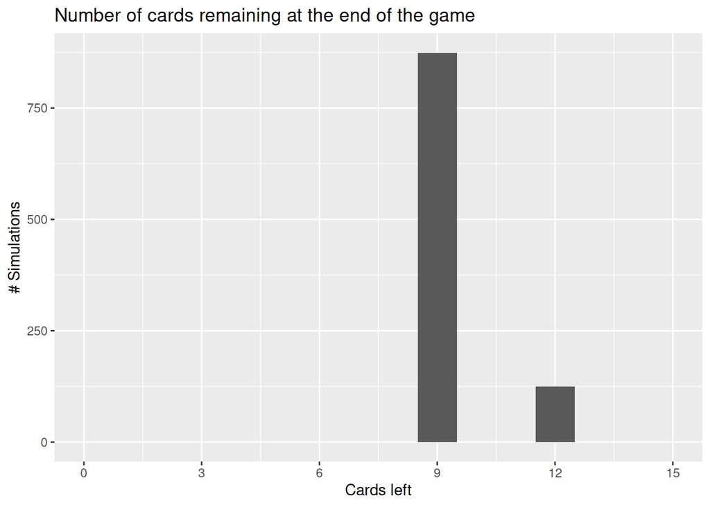

```r
ggplot(set_stats, aes(x = cards_left)) +
  geom_histogram(binwidth = 1) +
  scale_x_continuous("Cards left", limits = c(0, 15), breaks = seq(0, 15, by = 3)) +
  scale_y_continuous("# Simulations") +
  ggtitle("Number of cards remaining at the end of the game")
```

#### How often is there not a set in 12 cards?

##### In a game situation

First, we have to get the information out of our simulated trial data. We have the number of cards dealt in each round; to figure out how many rounds there were where there were 12 cards present and there wasn’t a set, we need to look for missing remove_set indices:

- deal 3 cards -> remove set -> 9 cards present (presumably)
- deal 3 cards -> 12 cards present -> remove_set but no set found -> 12 cards still there
- deal 3 cards -> 15 cards present -> remove_set

```r
set1000[[1]] %>%
  count(remove_note) %>%
  right_join(tibble(remove_note = 1:max(.$remove_note, na.rm = T))) %>%
  pluck("n") %>%
  is.na() %>%
  sum()
```

```
## [1] 4
```

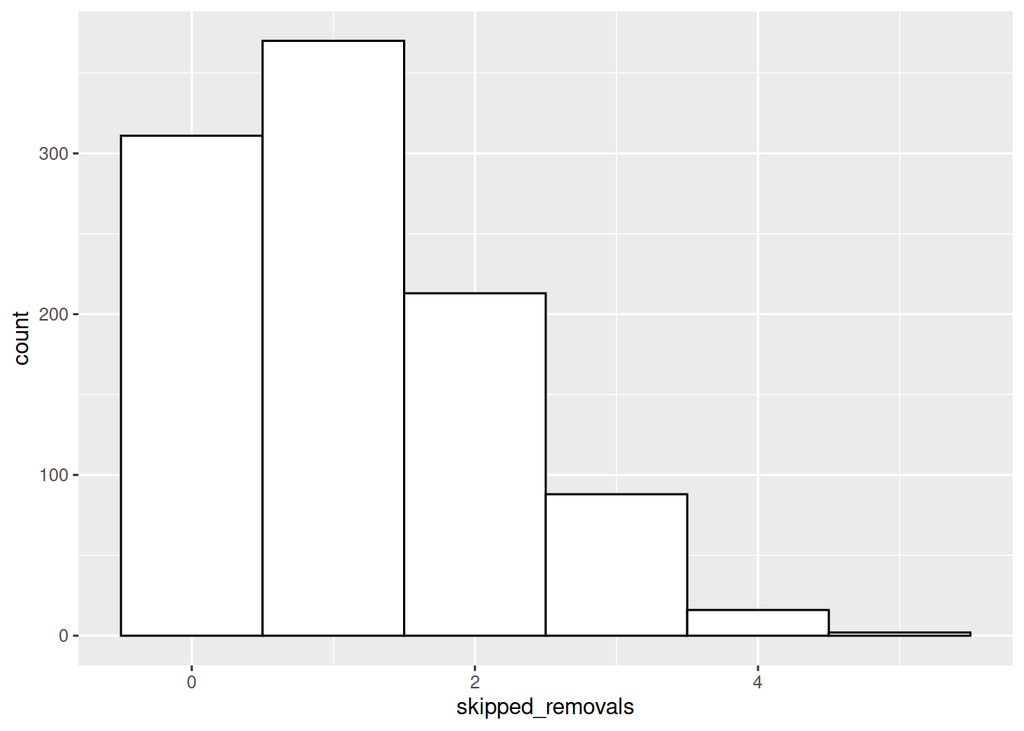

```r
count_missing_removals <- function(game) {
  game %>%
  count(remove_note) %>%
  right_join(tibble(remove_note = 1:max(.$remove_note, na.rm = T)), by = "remove_note") %>%
  pluck("n") %>%
  is.na() %>%
  sum()
}

set_stats <- set_stats %>%
  mutate(skipped_removals = purrr::map_int(data, count_missing_removals),
         number_rounds = purrr::map_dbl(data, ~max(.$remove_note, na.rm = T)))

ggplot(set_stats, aes(x = skipped_removals)) + geom_histogram(binwidth = 1, fill = "white", color = "black")
```

This tells us that in a normal set game, we would expect to have 1.134 instances where there is not an available set on the board. Given that each game has on average 25.007 rounds, we can calculate the percentage of rounds in each game which don’t have sets as 0.044.

##### In a random draw

We could also look at the distribution of initial deals to get a sense of the same basic issue outside of the context of a full game.

```r
draw_1000_sets <- replicate(1000, set_deck %>% deal_set(n = 12), simplify = F)
single_deal <- tibble(deal = draw_1000_sets, sets = purrr::map_int(deal, ~nrow(set_present(.))))
```

In this situation, the proportion of “fresh deals” without a set is 0.034.

We can conclude from this that it is more common to run into a combination of 12 cards that have no valid set in a full game than it is in a fresh random deal of 12 cards. This makes sense: once some sets have been removed from the deck, the remaining cards may be less likely to form a set (because critical cards aren’t available).

#### How long is a card on the table, on average?

We’ve recorded the round a card is dealt in, and the round a card is removed in, so we have a way to get the number of rounds a card sits on the table.

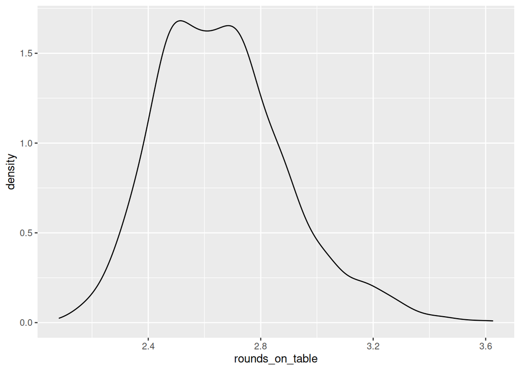

```r
set_stats <- set_stats %>%
  mutate(rounds_on_table = purrr::map_dbl(data, ~mean(.$remove_note - .$deal_note, na.rm = T)))

ggplot(set_stats, aes(x = rounds_on_table)) + geom_density()
```

Cards are on the table for an average of between 2 and 3.5 rounds; the mode is around 2.5. This is censored, however, because some cards always remain on the table.